AirBnB Project Ridge Regression and Lasso Model

```r
rm(list=ls())
setwd("~/R/Predictive Modeling AirBnB Project")
clean_listings = read.csv("clean_listings2.csv") #open the .csv file
head(clean_listings) #examine the data in window
```

```
##   latitude longitude       room_type guests_included minimum_nights
## 1 30.26112 -97.73448 Entire home/apt               2              2
## 2 30.45596 -97.78370    Private room               2              1
## 3 30.26027 -97.76503 Entire home/apt               2              3
## 4 30.23616 -97.73682 Entire home/apt               2              3
## 5 30.25012 -97.74193 Entire home/apt               4              2
## 6 30.15645 -97.82411 Entire home/apt               1              1
##   review_scores_rating         cancellation_policy host_is_superhost
## 1                   96 strict_14_with_grace_period                 t
## 2                   98                    moderate                 t
## 3                   99 strict_14_with_grace_period                 t
## 4                   92 strict_14_with_grace_period                 f
## 5                   94 strict_14_with_grace_period                 f
## 6                   98 strict_14_with_grace_period                 f
##   number_of_reviews number_of_reviews_ltm bathrooms bedrooms beds bed_type
## 1               490                    50         1        1    2 Real Bed
## 2               250                    19         1        1    1 Real Bed
## 3               210                    26         1        1    2 Real Bed
## 4                46                     2         1        1    1 Real Bed
## 5                47                     7         2        2    4 Real Bed
## 6                25                     2         2        3    3 Real Bed
##   four_nights_price has_reviews
## 1               380        TRUE
## 2               160        TRUE
## 3               516        TRUE
## 4               245        TRUE
## 5              1040        TRUE
## 6              1250        TRUE
```

## Validation Set

```r
x=model.matrix(four_nights_price~.,clean_listings)[,-1]
y=clean_listings$four_nights_price

set.seed(1)
train=sample(1:nrow(x), nrow(x)/2)
test=(-train)
y.test=y[test]
```

## Ridge Regression

We will use the package `glmnet`, which does not use the model formula language, so we will set up on an `x` and `y`.

```r
library(glmnet)
#x=model.matrix(four_nights_price~. -1, data=clean_listings)
#y=clean_listings$four_nights_price
```

Fit a ridge-regression model. This is achieved by calling `glmnet` with `alpha=0`

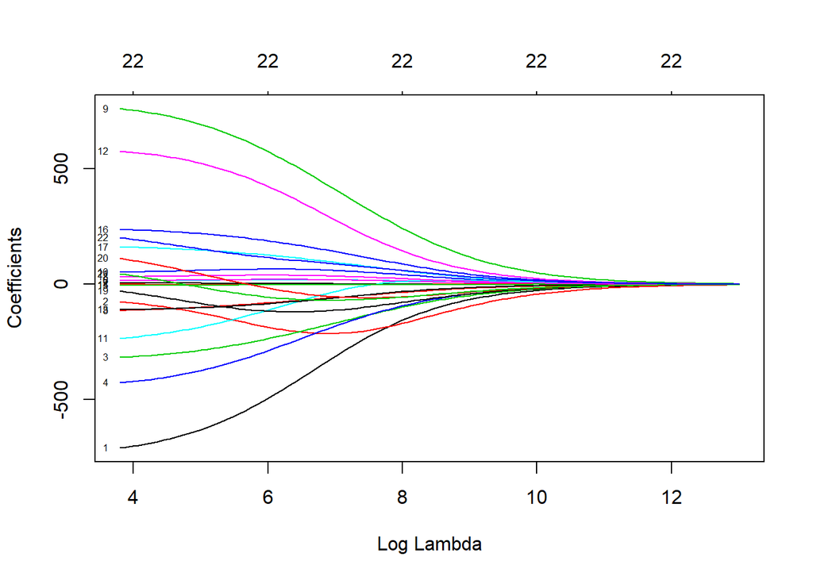

```r
fit.ridge=glmnet(x,y,alpha=0)
plot(fit.ridge, xvar="lambda", label=TRUE)
```

Now we will use the `cv.glmnet` function to do the cross-validation

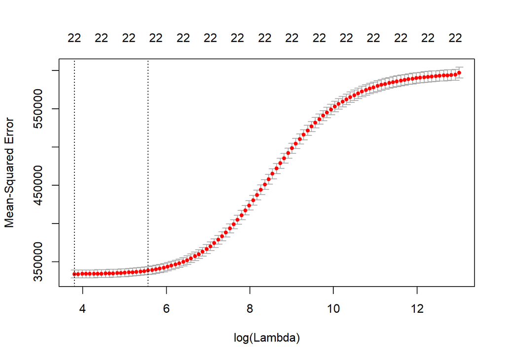

```r
cv.ridge=cv.glmnet(x,y,alpha=0)
plot(cv.ridge)
```

## Lasso

Now we fit a lasso model; for this we use the default `alpha=1`

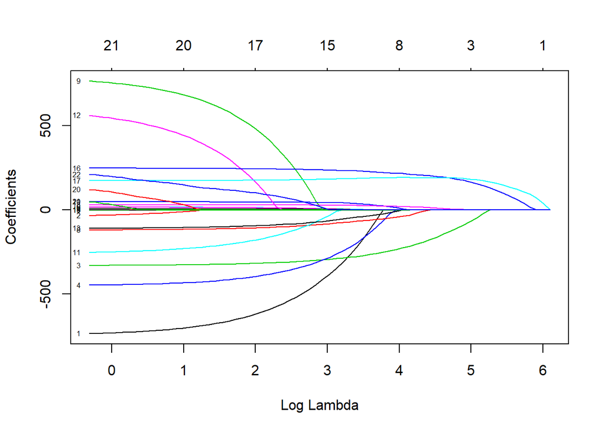

```r
fit.lasso=glmnet(x,y)
plot(fit.lasso, xvar="lambda", label=TRUE)
```

Percentage of deviance or R^2 explained (may be an indication that the end of the plot is overfit)

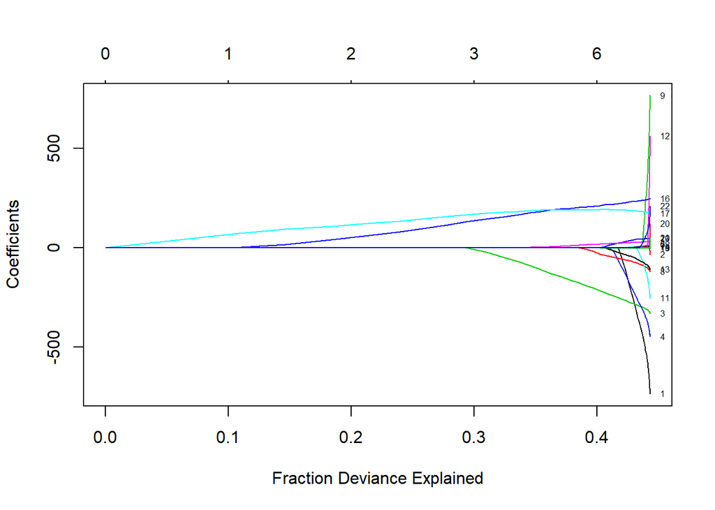

```r
fit.lasso=glmnet(x,y)
plot(fit.lasso, xvar="dev", label=TRUE)
```

Cross Validation for Lasso

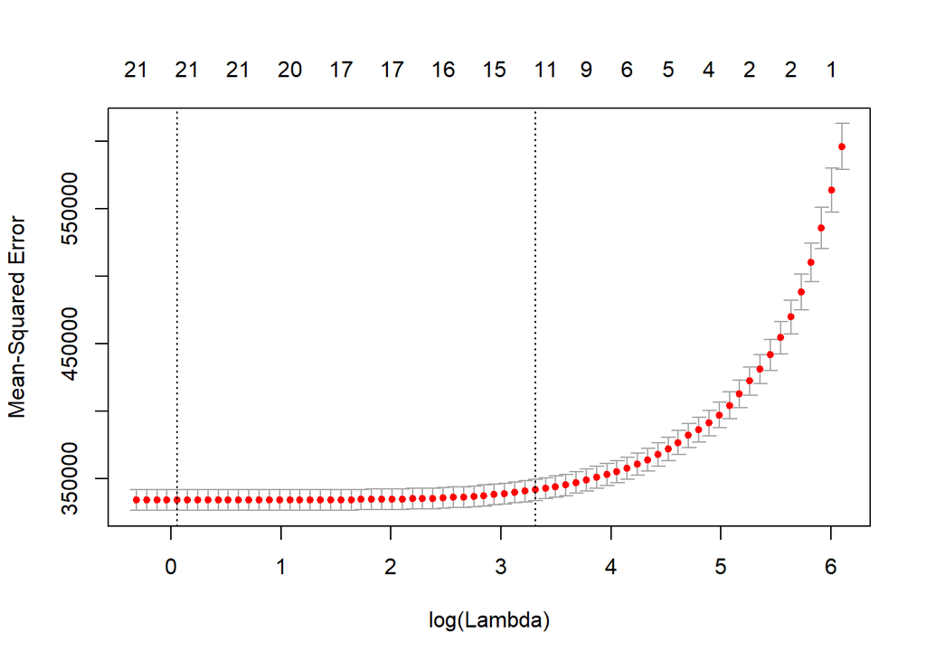

```r
cv.lasso = cv.glmnet(x, y)
plot(cv.lasso)
```

Extract the coefficient from the CV object, it’ll pick the coefficient vector corresponding to the best model

```r
coef(cv.lasso)
```

```
## 24 x 1 sparse Matrix of class "dgCMatrix"
##                                                           1
## (Intercept)                                    8422.8540611
## latitude                                       -269.5852741
## longitude                                         .
## room_typePrivate room                          -282.6712190
## room_typeShared room                           -221.8650631
## guests_included                                   2.2983900
## minimum_nights                                    1.1959210
## review_scores_rating                              0.4749911
## cancellation_policymoderate                     -72.1917461
## cancellation_policystrict                         .
## cancellation_policystrict_14_with_grace_period   38.9646148
## cancellation_policysuper_strict_30                .
## cancellation_policysuper_strict_60                .
## host_is_superhostt                              -50.4018692
## number_of_reviews                                 .
## number_of_reviews_ltm                            -3.4771185
## bathrooms                                       231.6598430
## bedrooms                                        184.6392152
## beds                                             25.1573288
## bed_typeCouch                                     .
## bed_typeFuton                                     .
## bed_typePull-out Sofa                             .
## bed_typeReal Bed                                  .
## has_reviewsTRUE                                   .
```

Suppose we want to use our earlier train/validation division to select the `lambda` for the lasso.

```r
lasso.tr=glmnet(x[train,],y[train])
lasso.tr
```

```
##
## Call:  glmnet(x = x[train, ], y = y[train])
##
##       Df    %Dev   Lambda
##  [1,]  0 0.00000 444.7000
##  [2,]  1 0.05734 405.2000
##  [3,]  2 0.10560 369.2000
##  [4,]  2 0.15090 336.4000
##  [5,]  2 0.18850 306.5000
##  [6,]  2 0.21980 279.3000
##  [7,]  2 0.24570 254.5000
##  [8,]  2 0.26730 231.8000
##  [9,]  2 0.28510 211.3000
## [10,]  3 0.30030 192.5000
## [11,]  4 0.31820 175.4000
```

[output cut: 59 more lines]

```r
#Summary of the glmnet fit -> For each of the models in the path, it gives:
# (1) The degrees of freedom, which is the number of non-zero coefficients
# (2) The percentage deviance explained, which is like r^2 but for generalized linear models
# (3) The lambda value that corresponds to that fit
```

```r
pred=predict(lasso.tr, x[-train,])
dim(pred)
```

```
## [1] 5181   70
```

Then we can look at our validation curve by by plotting RMSE as a function of Lambda To find the RMSE: (1) Compute our sum of squared errors (2) Use apply to compute the means in each column of the squared errors (3) Take the square root

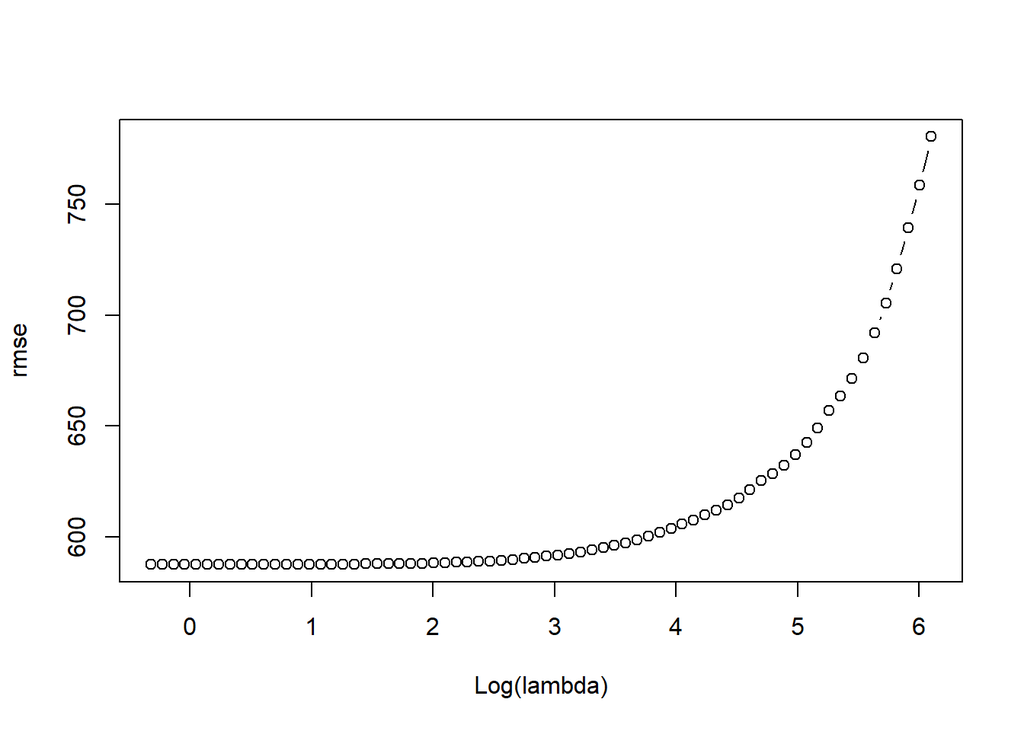

```r
rmse=sqrt(apply((y[-train]-pred)^2,2,mean))
plot(log(lasso.tr$lambda),rmse,type="b", xlab="Log(lambda)")
```

Next, we can extract the base lambda. We do this by indexing lambda in ascending order of rmse and picking out the index of the first (smallest) value.

```r
lam.best=lasso.tr$lambda[order(rmse)[1]]
lam.best
```

```
## [1] 0.7246872
```

Now we can look at the coefficients corresponding to lam.best That’ll give us a subset of the coefficients (our coefficient vector)

```r
coef(lasso.tr, s=lam.best)
```

```
## 24 x 1 sparse Matrix of class "dgCMatrix"
##                                                           1
## (Intercept)                                    6300.6678078
## latitude                                       -691.8383734
## longitude                                      -145.4671219
## room_typePrivate room                          -323.6731967
## room_typeShared room                           -486.3413928
## guests_included                                   9.4341664
## minimum_nights                                   16.7431712
## review_scores_rating                              5.3849942
## cancellation_policymoderate                    -101.1370833
## cancellation_policystrict                       592.1422544
## cancellation_policystrict_14_with_grace_period   41.7494087
## cancellation_policysuper_strict_30             -275.5665273
## cancellation_policysuper_strict_60              567.7841216
## host_is_superhostt                             -107.7262274
## number_of_reviews                                -0.0643689
## number_of_reviews_ltm                            -4.2185669
## bathrooms                                       251.1090550
## bedrooms                                        163.4649215
## beds                                             42.9597210
## bed_typeCouch                                    -6.8951215
## bed_typeFuton                                   122.2752148
## bed_typePull-out Sofa                            68.5655873
## bed_typeReal Bed                                186.5441638
## has_reviewsTRUE                                   .
```